# Update Reassure

renyan

2022/5/5

# 阶段总结

## 现有进展

- 模拟数据生成
- 初始化
- 模型循环体
- 迭代过程细节
- 模型评估
- 调参
- …

## 待改进细节

- $\rho$ 的设定，不同分组公用还是每个组单独定义
- $\beta, \gamma$ 在 MCP 中惩罚的参数相同

```
## character(0)
```

# 模拟数据生成

```r
n <- 120                         # The sample size
p <- 10                           # The dimension of x
q <- 5                         # The dimension of z
pq <- q*p                        # The dimension of each sample
dim_nonzero_beta <- 2                         # The dimension of non-zero coefficients of x
dim_nonzero_alpha <- 2                        # The dimension of non-zero coefficients of z
dim_nonzero_gamma <- 4
balance <- T                     # Balanced/Imbalanced subgroup
gr_num_main <- 2                     # The number of rough subgroup
gr_num_sub <- 4                       # The number of refined subgroup
hier_struc <- list(c(1,2),c(3,4))  # Hierarchical subgroup structure
# sd.epsi<-0.5                     # The residual error
# corZX <- F                       # Correlated/Uncorrelated X and Z
intercorr0<-"AR1"                # The correlation structure of Z
signal_its <- 6 # signal intensity
K <- gr_num_sub
iter_max <- 10
set.seed(9)

# ------------ Necessary parameters to support algorithm implementation --------
comb_pair <- combn(K,2)
H_3 <- kronecker(Matrix(t(apply(comb_pair,2,dMatrixFun)),sparse = T),bdiag(diag(pq)))
H_1 <- kronecker(Matrix(t(apply(comb_pair,2,dMatrixFun)),sparse = T),bdiag(diag(p)))
H_2 <- kronecker(Matrix(t(apply(comb_pair,2,dMatrixFun)),sparse = T),bdiag(diag(q)))

# ------------ Generate the regression coefficients -----------
coef_main_value <- c(signal_its, -signal_its)
coef_sub_value <- c(1.5*signal_its, 0.5*signal_its, -0.5*signal_its, -1.5*signal_its)
if(balance){pr_sub<-rep(1/gr_num_sub,gr_num_sub)}else{pr_sub<-c(1/6,1/6,1/3,1/3)}

# true main groups & subgroups
ci <- ci_generate(n, pr_sub, hier_struc)
ci_sim <- rep(0, n) # true label
for(i in 1:K){
  ci_sim[ci$ci_sub[[i]]] <- i
}

# true coefficients
coef_true <- generate_coef_true(n, p, q, ci$ci_main, ci$ci_sub,
                                coef_main_value,  coef_sub_value,
                                dim_nonzero_beta, dim_nonzero_alpha, dim_nonzero_gamma)
# Generate data
whole.data <- generate_sim_data(n, p, q, coef_true, cotype_x="AR_E", cotype_z="AR_E")
```

# Model

## Initialization

```r
set.seed(99)
fmr <- initialize_coef(whole.data, p, q)
```

```r
# table(ci_sim, fmr$ci_weight)
# table(ci_sim, fmr$ci_res)
prop.table(table(fmr$ci_weight))
```

```
##
##         1         2         3         4
## 0.1416667 0.4750000 0.1666667 0.2166667
```

```r
prop.table(table(fmr$ci_res))
```

```
##
##         1         2         3         4
## 0.2500000 0.2916667 0.2416667 0.2166667
```

```r
cat(sc(fmr$ci_weight, ci_sim),
        sc(fmr$ci_res, ci_sim),
        sc(fmr$ci_res, fmr$ci_weight))
```

```
## 0.5984594 0.6323529 0.8016807
```

```r
# df_tmp <- data.frame(y = whole.data$data_y,
#                      y_weight = fmr$y_weight,
#                      y_res = fmr$y_res)
#
# df_plot <- melt(df_tmp)
# ggplot(df_plot, aes(x = value, fill = variable)) +
#   geom_histogram(position = 'dodge', binwidth = 50) +
#   theme_minimal()
```

- 两种分类标准效果：使用不同成分得到的残差比直接使用权重的效果好

```r
# sc_weight <- NULL
# sc_res <- NULL
# pk <- NULL
# rho_weight <- NULL
# rho_res <- NULL
# mu_weight <- NULL
# mu_res <- NULL
#
# for(i in 1:200){
#   fmr <- initialize_coef(whole.data, p, q)
#   sc_weight[i] <- sc(fmr$ci_weight, ci_sim)
#   sc_res[i] <- sc(fmr$ci_res, ci_sim)
#   rho_weight[[i]] <- fmr$rho_k_weight
#   rho_res[[i]] <- fmr$rho_k_res
#   mu_weight[[i]] <- fmr$mu_k_weight
#   mu_res[[i]] <- fmr$mu_k_res
#   pk[[i]] <- fmr$pi_k
# }
#
# cnames <- c(paste("weight", 1:4, sep = "."), paste("res", 1:4, sep = "."))
# df_rho <- cbind(do.call(rbind, rho_weight), do.call(rbind, rho_res))
# df_mu <- cbind(do.call(rbind, mu_weight), do.call(rbind, mu_res))
# colnames(df_rho) <- cnames
# colnames(df_mu) <- cnames
#
# write.csv(do.call(rbind, pk), file = "20220511_pi.csv", row.names = FALSE)
# write.csv(df_rho, file = "20220511_rho.csv", row.names = FALSE)
# write.csv(df_mu, file = "20220511_mu.csv", row.names = FALSE)
# write.csv(data.frame(sc_weight = sc_weight, sc_res = sc_res), file = "20220511_sc.csv", row.names = FALSE)
```

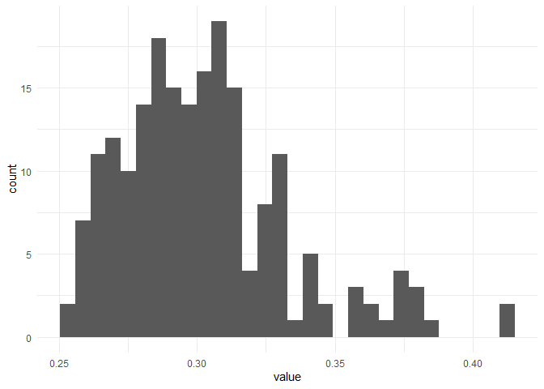

```r
df_pk <- read.csv("20220511_pi.csv") %>% rowwise() %>%
  transmute(pi_max = max(Comp.1, Comp.2, Comp.3, Comp.4)) %>% melt()
df_rho <- read.csv("20220511_rho.csv") %>% rowwise() %>%
  transmute(rho_min_weight = min(weight.1, weight.2, weight.3, weight.4),
         rho_min_res = min(res.1, res.2, res.3, res.4)) %>% melt()
df_mu <- read.csv("20220511_mu.csv") %>% rowwise() %>%
  transmute(mu_sd_weight = sd(c(weight.1, weight.2, weight.3, weight.4)),
         mu_sd_res = sd(c(res.1, res.2, res.3, res.4))) %>% melt()
df_sc <- read.csv("20220511_sc.csv") %>% melt()

ggplot(df_pk, aes(x = value)) +
  geom_histogram() +
  theme_minimal()
```

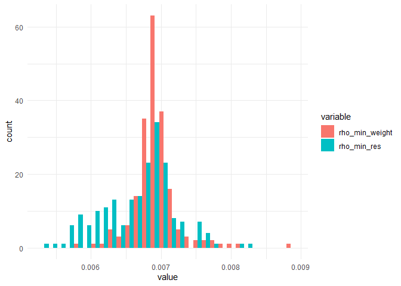

```r
ggplot(df_rho, aes(x = value, fill = variable)) +
  geom_histogram(position = 'dodge') +
  theme_minimal()
```

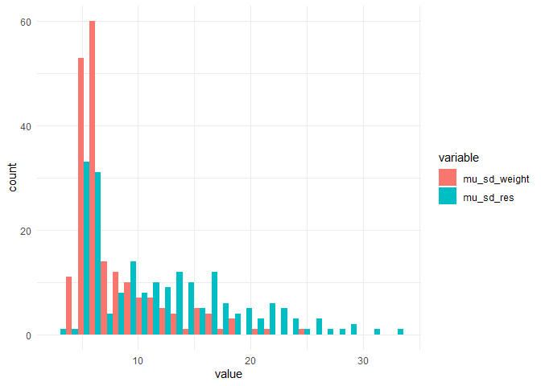

```r
ggplot(df_mu, aes(x = value, fill = variable)) +
  geom_histogram(position = 'dodge') +
  theme_minimal()
```

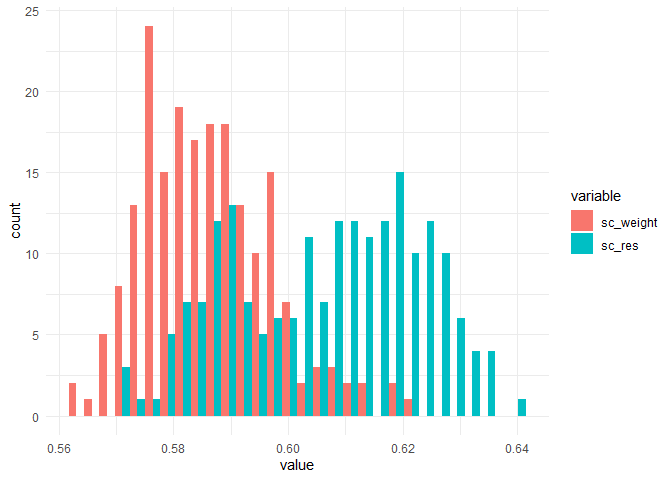

```r
ggplot(df_sc, aes(x = value, fill = variable)) +
  geom_histogram(position = 'dodge') +
  theme_minimal()
```

## Iteration-1

```r
coef_init <- fmr$info$coef

# 按列索引
idx_X <- c(1:(p))
idx_Z <- c((p+1):((p+q)))
idx_W <- c(((p+q)+1):((p+q+pq)))
idx_X_full <- sort(rep((0:(K-1))*(p+q+pq), p)) + idx_X
idx_Z_full <- sort(rep((0:(K-1))*(p+q+pq), q)) + idx_Z
idx_W_full <- sort(rep((0:(K-1))*(p+q+pq), pq)) + idx_W
coef_init_beta <- coef_init[idx_X_full]
coef_init_alpha <- coef_init[idx_Z_full]
coef_init_eta <- coef_init[idx_W_full]
coef_init_gamma <- coef_init_eta/kronecker(coef_init_beta, matrix(1, nrow=q, ncol=1))

X <- whole.data$X_all
y <- whole.data$data_y

####################### Initialize coef ######################
# group
# *1 sgeMatrix
u_init <- H_1 %*% coef_init_beta
v_init <- H_2 %*% coef_init_alpha
w_init <- H_3 %*% coef_init_gamma
# *1 sgeMatrix
xi_init <- Matrix(0, ncol=1, nrow=p*K*(K-1)/2, sparse=T)
zeta_init <- Matrix(0, ncol=1, nrow=q*K*(K-1)/2, sparse=T)
eta_init <- Matrix(0, ncol=1, nrow=pq*K*(K-1)/2, sparse=T) # 字母有混淆，暂且这么记

# iteration
# weight/res 相关选择在这里修改
# 根据分析暂时选择使用 res 相关
iter <- 1
coef_beta_est_list <- vector(mode="list", length=iter_max)
coef_alpha_est_list <- vector(mode="list", length=iter_max)
coef_eta_est_list <- vector(mode="list", length=iter_max)
coef_gamma_est_list <- vector(mode="list", length=iter_max)
coef_beta_est_list[[iter]] <- coef_init_beta
coef_alpha_est_list[[iter]] <- coef_init_alpha
coef_eta_est_list[[iter]] <- coef_init_eta
coef_gamma_est_list[[iter]] <- coef_init_gamma

u_est_list <- vector(mode="list", length=iter_max); u_est_list[[iter]] <- u_init
v_est_list <- vector(mode="list", length=iter_max); v_est_list[[iter]] <- v_init
w_est_list <- vector(mode="list", length=iter_max); w_est_list[[iter]] <- w_init

xi_est_list <- vector(mode="list", length=iter_max)
zeta_est_list <- vector(mode="list", length=iter_max)
eta_est_list <- vector(mode="list", length=iter_max)
xi_est_list[[iter]] <- xi_init
zeta_est_list[[iter]] <- zeta_init
eta_est_list[[iter]] <- eta_init

rho_est_list <- vector(mode="list", length=iter_max)
rho_est_list[[iter]] <- fmr$rho_k_res
mu_est_list <- vector(mode="list", length=iter_max)
mu_est_list[[iter]] <- fmr$mu_k_res
pi_est_list <- vector(mode="list", length=iter_max)
pi_est_list[[iter]] <- fmr$pi_k

y_est_list <- vector(mode="list", length=iter_max)
y_est_list[[iter]] <- fmr$y_res
```

## Iteration-n

ADMM 算法循环体

```r
iter_max <- 5
K_up <- 4
tau <- 1

H_1_prod <- t(H_1)%*%H_1
H_2_prod <- t(H_2)%*%H_2
H_3_prod <- t(H_3)%*%H_3

lambda_1 <- 1
lambda_2 <- 1
lambda_3 <- 1
a <- 3
```

### Test Part

（省略）

### Full Iteration

```r
# full iteration
iter_max <- 10
for(iter in 2:iter_max){
  pi_k <- pi_est_list[[iter-1]]
  q_c_matrix <- matrix(0, nrow = n, ncol = K_up)
  for(k in 1:K_up){
    q_c_matrix[,k] <- dnorm(y_est_list[[iter-1]],
                            mean = mu_est_list[[iter-1]][k],
                            sd = 1/rho_est_list[[iter-1]][k])
  }
  q_c_matrix <- q_c_matrix * kronecker(matrix(1, nrow = n, ncol = 1), matrix(pi_k, nrow = 1))
  q_c_matrix <- q_c_matrix/apply(q_c_matrix, 1, sum)

  # ======================================= PART 1 =======================================
  for(k in 1:K_up){
    b_k_common <- 1/tau * sum(q_c_matrix[,k] *
                                rho_est_list[[iter-1]][k]**2 *
                                (whole.data$data_y - mu_est_list[[iter-1]][k]))
    # -------------------------------------- PART 1.1 --------------------------------------
    # alpha_k
    A_k <- (H_2_prod)[((k-1)*q+1):(k*q),]
    b_k1 <- t(H_2)[((k-1)*q+1):(k*q),]%*%(v_est_list[[iter-1]]-1/tau*zeta_est_list[[iter-1]])
    b_k2 <- apply(q_c_matrix[,k] * whole.data$Z, 2, sum)
    b_k <- b_k1 + b_k_common * b_k2 # 矩阵+元组=>矩阵
    coef_alpha_est_list[[iter]][((k-1)*q+1):(k*q)] <- qr.solve(A_k, b_k)[1:q]

    # -------------------------------------- PART 1.2 --------------------------------------
    # beta_k
    beta_k <- coef_beta_est_list[[iter-1]][((k-1)*p+1):(k*p)]
    gamma_k <- coef_gamma_est_list[[iter-1]][((k-1)*pq+1):(k*pq)]
    beta_shrink_case <- (abs(beta_k) <= a*lambda_1)

    A_k <- (H_1_prod)[((k-1)*p+1):(k*p),]
    b_k1 <- t(H_1)[((k-1)*p+1):(k*p),]%*%(u_est_list[[iter-1]]-1/tau*xi_est_list[[iter-1]])
    b_k2 <- apply(q_c_matrix[,k] * (whole.data$X + as.numeric(whole.data$W%*%matrix(gamma_k, ncol=1))), 2, sum)
    b_k_shrink <- 1/tau * sign(beta_k) * (lambda_1 - 1/a*abs(beta_k))
    b_k <- b_k1 + b_k_common * b_k2
    b_k[beta_shrink_case] <- b_k[beta_shrink_case] - b_k_shrink[beta_shrink_case]
    coef_beta_est_list[[iter]][((k-1)*p+1):(k*p)] <- qr.solve(A_k, b_k)[1:p]


    # -------------------------------------- PART 1.3 --------------------------------------
    # gamma_k
    beta_k <- coef_beta_est_list[[iter-1]][((k-1)*p+1):(k*p)]
    gamma_k <- coef_gamma_est_list[[iter-1]][((k-1)*pq+1):(k*pq)]
    gamma_shrink_case <- (abs(gamma_k) <= a*lambda_1)

    A_k <- (H_3_prod)[((k-1)*pq+1):(k*pq),]
    b_k1 <- t(H_3)[((k-1)*pq+1):(k*pq),]%*%(w_est_list[[iter-1]]-1/tau*eta_est_list[[iter-1]])
    b_k2 <- sum(q_c_matrix[,k] * as.numeric(whole.data$W%*%matrix(rep(beta_k, q), ncol=1)))
    b_k_shrink <- 1/tau * sign(gamma_k) * (lambda_1 - 1/a*abs(gamma_k))
    b_k <- b_k1 + b_k_common * b_k2
    b_k[gamma_shrink_case] <- b_k[gamma_shrink_case] - b_k_shrink[gamma_shrink_case]
    coef_gamma_est_list[[iter]][((k-1)*pq+1):(k*pq)] <- qr.solve(A_k, b_k)[1:pq]
  }
  coef_eta_est_list[[iter]] <- kronecker(coef_beta_est_list[[iter]], matrix(1, nrow=q, ncol=1)) * coef_gamma_est_list[[iter]]
  # ======================================= PART 2 =======================================
  for(k in 1:K_up){
    u_hat <- H_1 %*% coef_beta_est_list[[iter]] + 1/tau * xi_est_list[[iter-1]]
    v_hat <- H_2 %*% coef_alpha_est_list[[iter]] + 1/tau * zeta_est_list[[iter-1]]
    w_hat <- H_3 %*% coef_gamma_est_list[[iter]] + 1/tau * eta_est_list[[iter-1]]
    # each column corresponds to one kk' pair
    u_hat_matrix <- matrix(u_hat, nrow = p)
    v_hat_matrix <- matrix(v_hat, nrow = q)
    w_hat_matrix <- matrix(w_hat, nrow = pq)

    # all hats
    phi_norm2_1 <- apply(rbind(u_hat_matrix, v_hat_matrix, w_hat_matrix),
                         2, function(x){sqrt(sum(x**2))})
    psi_norm2_1 <- apply(rbind(u_hat_matrix, v_hat_matrix),
                        2, function(x){sqrt(sum(x**2))})
    w_norm2_1 <- apply(w_hat_matrix, 2, function(x){sqrt(sum(x**2))})

    phi_coe <- abs(1-lambda_2/tau/phi_norm2_1)/(1-1/a/tau)
    psi_coe <- abs(1-lambda_3/tau/psi_norm2_1)/(1-1/a/tau)
    kkpair_idx_nn <- which((phi_norm2_1>a*lambda_2) & (psi_norm2_1>a*lambda_3))
    kkpair_idx_sn <- which((phi_coe*phi_norm2_1<=a*lambda_2) & (psi_coe*psi_norm2_1>a*lambda_3))
    kkpair_idx_ns <- which(((phi_coe*phi_norm2_1)**2+(w_norm2_1)**2>(a*lambda_2)**2) &
                             (psi_coe*psi_norm2_1<=a*lambda_3))
    kkpair_idx_ss <- setdiff(1:(K_up*(K_up-1)/2),
                             Reduce(union,list(kkpair_idx_nn,kkpair_idx_sn,kkpair_idx_ns)))

    u_est_list[[iter]] <- matrix(0, nrow = p*(K_up*(K_up-1)/2))
    v_est_list[[iter]] <- matrix(0, nrow = q*(K_up*(K_up-1)/2))
    w_est_list[[iter]] <- matrix(0, nrow = pq*(K_up*(K_up-1)/2))
    # case1: no shrinkage
    if(length(kkpair_idx_nn) > 0){
      for(kk in kkpair_idx_nn){
        u_est_list[[iter]][((kk-1)*p+1):(kk*p)] <- u_hat[((kk-1)*p+1):(kk*p)]
        v_est_list[[iter]][((kk-1)*q+1):(kk*q)] <- v_hat[((kk-1)*q+1):(kk*q)]
        w_est_list[[iter]][((kk-1)*pq+1):(kk*pq)] <- w_hat[((kk-1)*pq+1):(kk*pq)]
      }
    }
    # case2: overall shrinkage (prop)
    if(length(kkpair_idx_sn > 0)){
      for(kk in kkpair_idx_nn){
        u_est_list[[iter]][((kk-1)*p+1):(kk*p)] <- phi_coe[kk] * u_hat[((kk-1)*p+1):(kk*p)]
        v_est_list[[iter]][((kk-1)*q+1):(kk*q)] <- phi_coe[kk] * v_hat[((kk-1)*q+1):(kk*q)]
        w_est_list[[iter]][((kk-1)*pq+1):(kk*pq)] <- phi_coe[kk] * w_hat[((kk-1)*pq+1):(kk*pq)]
      }
    }
    if(length(kkpair_idx_ns > 0)){
      for(kk in kkpair_idx_nn){
        u_est_list[[iter]][((kk-1)*p+1):(kk*p)] <- psi_coe[kk] * u_hat[((kk-1)*p+1):(kk*p)]
        v_est_list[[iter]][((kk-1)*q+1):(kk*q)] <- psi_coe[kk] * v_hat[((kk-1)*q+1):(kk*q)]
        w_est_list[[iter]][((kk-1)*pq+1):(kk*pq)] <- w_hat[((kk-1)*pq+1):(kk*pq)]
      }
    }
    if(length(kkpair_idx_ss > 0)){
      for(kk in kkpair_idx_nn){
        u_est_list[[iter]][((kk-1)*p+1):(kk*p)] <- u_hat[((kk-1)*p+1):(kk*p)]/
                    (1+(lambda_2/phi_norm2_1[kk]-1/a)/tau+(lambda_3/psi_norm2_1[kk]-1/a)/tau)
        v_est_list[[iter]][((kk-1)*q+1):(kk*q)] <- v_hat[((kk-1)*q+1):(kk*q)]/
                    (1+(lambda_2/phi_norm2_1[kk]-1/a)/tau+(lambda_3/psi_norm2_1[kk]-1/a)/tau)
        w_est_list[[iter]][((kk-1)*pq+1):(kk*pq)] <- w_hat[((kk-1)*pq+1):(kk*pq)]/
                    (1+(lambda_2/phi_norm2_1[kk]-1/a)/tau+(lambda_3/psi_norm2_1[kk]-1/a)/tau)
      }
    }
  }

  # ======================================= PART 3 =======================================
  xi_est_list[[iter]] <- xi_est_list[[iter-1]] +
    tau*(H_1 %*% coef_beta_est_list[[iter]] - u_est_list[[iter-1]])
  zeta_est_list[[iter]] <- zeta_est_list[[iter-1]] +
    tau*(H_2 %*% coef_alpha_est_list[[iter]] - v_est_list[[iter-1]])
  eta_est_list[[iter]] <- eta_est_list[[iter-1]] +
    tau*(H_3 %*% coef_gamma_est_list[[iter]] - w_est_list[[iter-1]])

  # ======================================= PART 4 =======================================
  # rho
  coef_eta <- kronecker(coef_beta_est_list[[iter]], matrix(1, q, 1)) * coef_gamma_est_list[[iter]]

  y_est_list[[iter]] <- apply((whole.data$X %*% matrix(coef_beta_est_list[[iter]], ncol=K_up) +
    whole.data$Z %*% matrix(coef_alpha_est_list[[iter]], ncol=K_up) +
    whole.data$W %*% matrix(coef_eta, ncol=K_up)) * q_c_matrix, 1, sum)

  rho_est_list[[iter]] <- sqrt(apply(q_c_matrix, 2, sum) /
    (apply(kronecker(y_est_list[[iter]], matrix(1, nrow=1, ncol=K_up)) -
           kronecker(matrix(pi_est_list[[iter-1]], nrow=1), matrix(1, nrow=n, ncol=1)), 2, sum))**2)

  mu_est_list[[iter]] <- (whole.data$X %*% matrix(coef_beta_est_list[[iter]], ncol=K_up) +
    whole.data$Z %*% matrix(coef_alpha_est_list[[iter]], ncol=K_up) +
    whole.data$W %*% matrix(coef_eta, ncol=K_up)) * q_c_matrix
  mu_est_list[[iter]] <- apply(mu_est_list[[iter]], 2, mean)

  # ====================================== E 步补充 ======================================
  # 此步更新，mu，qc 更新在 M 步之前完成
  pi_est_list[[iter]] <- apply(q_c_matrix, 2, mean)
}
```

```r
pi_est_list
```

```
## [[1]]
##        Comp.1   Comp.2    Comp.3    Comp.4
## [1,] 0.261865 0.318911 0.2555893 0.1636347
##
## [[2]]
## [1] 0.14454486 0.22004501 0.54198203 0.09342809
##
## [[3]]
## [1] 0.09849603 0.17867308 0.66596859 0.05686230
##
## [[4]]
## [1] 0.1759762 0.1859357 0.3613265 0.2767616
##
## [[5]]
## [1] 0.2971561 0.1983905 0.2888293 0.2156241
##
## [[6]]
## [1] 0.2051034 0.3282037 0.2041572 0.2625357
##
## [[7]]
## [1] 0.2516514 0.2602489 0.2538089 0.2342908
##
## [[8]]
## [1] 0.1275354 0.1148778 0.3032396 0.4543472
##
## [[9]]
## [1] 0.08651564 0.07429143 0.30141738 0.53777554
##
## [[10]]
## [1] 0.1615175 0.1582643 0.2620460 0.4181722
```

```r
lapply(y_est_list, mean)
```

```
## [[1]]
## [1] 5.561385
##
## [[2]]
## [1] 1.355421e+44
##
## [[3]]
## [1] -5.963777e+21
##
## [[4]]
## [1] -2.892533e+44
##
## [[5]]
## [1] -2.113082e+44
##
## [[6]]
## [1] -2.774716e+45
##
## [[7]]
## [1] 6.412005e+45
##
## [[8]]
## [1] 1.292314e+46
##
## [[9]]
## [1] 2.083858e+48
##
## [[10]]
## [1] 8.196528e+44
```

```r
coef_beta_est_list
```

```
## [[1]]
##  [1] -4.443614e+01 -1.985699e+01  7.182105e+00  6.084895e+01 -1.079716e+01
##  [6] -6.413361e+00  2.782830e+00  2.172183e+01 -4.054137e+01 -2.464000e+01
## [11]  4.062164e-18  2.865202e+01 -6.571891e+01 -2.725196e+01 -6.221231e+01
## [16]  5.055189e+01  3.976573e+01  7.631059e+01 -2.088118e-18 -1.243086e+01
## [21]  4.434212e-20 -1.008298e+01 -3.699154e+01  2.834765e+01  5.913813e+01
## [26]  7.882479e-20 -4.490739e+01  4.594791e+01  1.160885e+01 -3.214753e+01
## [31]  3.061524e+01 -1.258993e-21  8.393856e+00  3.255741e-21  2.934212e+01
## [36] -2.550277e+01 -9.704269e-22  1.466194e+01  9.132701e+00 -2.921164e+01
##
## [[2]]
##  [1] -5.612619e+01 -2.752602e+01  3.713898e+01  5.903407e+01 -2.102897e+01
##  [6] -1.623046e+01  3.011370e+00 -2.538459e+01 -4.891714e+01 -1.519865e+00
## [11]  1.406181e+17  1.406181e+17  1.406181e+17  1.406181e+17  1.406181e+17
## [16]  1.406181e+17  1.406181e+17  1.406181e+17  1.406181e+17  1.406181e+17
```

[output cut: 84 more lines]

```r
coef_alpha_est_list
```

```
## [[1]]
##  [1]  3.270706e+00  3.526506e+00  4.117744e+01  3.879849e+01 -2.578956e+01
##  [6] -8.771351e+00 -1.013522e+01  2.259685e+01  1.699118e-18 -1.600976e+01
## [11]  2.951309e+01 -1.827854e+00 -2.675221e+01 -6.001628e+01  3.386595e+01
## [16]  2.239070e-20  4.235677e-21  8.705792e-21 -2.708273e-21  3.505073e-22
##
## [[2]]
##  [1]   -3.637008    7.513860   42.564628   58.793136  -31.756205   59.095322
##  [7]   32.101868  -53.367380  -21.214986   56.112731  -91.560529    1.122160
## [13]  147.408411  221.247726 -148.012178   23.910634   -8.500020   37.009271
## [19]  -21.198922   -7.981756
##
## [[3]]
##  [1]   -3.643207    7.514197   42.562560   58.803920  -31.741626   59.097851
##  [7]   32.104310  -53.365314  -21.217784   56.105666  -94.039917   -1.125151
## [13]  144.030914  218.847328 -143.397174   24.012445   -8.436568   37.022081
## [19]  -21.217784   -7.933368
##
## [[4]]
##  [1]   -0.7854840   -0.7274767   -1.1188054   -0.8181362    1.5375298
##  [6] -248.5728684  -96.1696058  387.0844506  322.4868993 -356.0883322
## [11]  354.0505348   27.7492274 -416.0187124 -647.3639482  460.4113051
## [16] -107.8341185   66.2379484   25.5778456  322.4226402  -99.7103834
##
## [[5]]
##  [1]     2.857723    -8.241674   -43.681366   -59.622056    33.279155
##  [6]  -558.634951  -226.634368   824.161264   663.791500  -763.583163
## [11]   809.677292    63.431771  -965.923043 -1506.384909  1050.430675
## [16]  -242.469171   138.477577    10.717682   663.727241  -187.010047
##
## [[6]]
##  [1]     3.643207    -7.514197   -42.562560   -58.803920    31.741626
##  [6]   681.087455   251.303754 -1115.736210  -951.915542  1023.008618
## [11]  -963.717318   -78.224273  1109.695297  1727.162287 -1245.475731
## [16]   293.559485  -195.622072  -121.646768  -951.658505   317.691990
##
## [[7]]
##  [1]     0.7854840     0.7274767     1.1188054     0.8181362    -1.5375298
##  [6]  3485.6931012  1351.5089012 -5411.2679950 -4509.3612652  4974.0410518
## [11] -5000.6728844  -428.3498217  5764.5850506  9020.5986064 -6364.5124865
## [16]  1517.3362352  -920.9766494  -349.9606394 -4508.7829325  1385.8588452
##
## [[8]]
##  [1]   -2.857723    8.241674   43.681366   59.622056  -33.279155   94.828654
##  [7]   64.933344   -2.837185   15.000765  -14.035534 -167.513463  -67.285246
## [13]   45.858323  149.571490  -10.167330   64.111639   27.076922   88.022960
## [19]   14.293914  -75.634602
##
## [[9]]
##  [1]     -3.643207      7.514197     42.562560     58.803920    -31.741626
##  [6] -17330.494916  -6689.701255  27057.978011  22565.079636 -24890.390913
## [11]  24838.992895   2077.373769 -28772.591709 -44950.148997  31806.244983
## [16]  -7519.427601   4634.870076   1842.301379  22561.481121  -7011.078947
##
## [[10]]
##  [1] -7.854840e-01 -7.274767e-01 -1.118805e+00 -8.181362e-01  1.537530e+00
##  [6] -1.781607e+04 -6.981401e+03  2.724689e+04  2.272856e+04 -2.495333e+04
## [11]  2.566513e+04  2.446767e+03 -2.882716e+04 -4.545952e+04  3.172397e+04
## [16] -7.851417e+03  4.532452e+03  1.576912e+03  2.272850e+04 -6.766023e+03
```

```r
coef_gamma_est_list
```

```
## [[1]]
##                 [,1]
##   [1,] -1.497409e+00
##   [2,]  2.613758e+00
##   [3,] -3.227270e-02
##   [4,] -8.558850e-01
##   [5,]  2.490928e+00
##   [6,]  4.467541e-01
##   [7,] -1.845672e-01
##   [8,] -3.829388e+00
##   [9,] -5.663560e+00
##  [10,]  9.462708e-01
##  [11,] -6.421434e+00
##  [12,]  1.207973e+01
##  [13,]  5.716924e+00
```

[output cut: 565 more lines]

```r
ci_current <- apply(q_c_matrix, 1, which.max)
ci_current
```

```
##   [1] 4 4 2 3 2 1 4 2 4 4 3 4 4 4 4 4 4 4 4 4 1 4 4 4 4 4 4 1 4 1 4 4 4 4 1 4 4
##  [38] 1 4 4 1 1 4 4 3 4 2 4 4 4 4 2 1 3 4 4 4 4 4 2 4 2 4 4 4 4 1 3 4 1 4 1 4 3
##  [75] 4 3 4 4 4 4 4 4 4 4 1 1 4 3 1 2 4 4 1 3 4 4 4 4 4 1 4 1 4 2 4 3 3 4 4 2 1
## [112] 3 4 4 4 4 4 2 4 4
```

```r
sc(ci_current, ci_sim)
```

```
## [1] 0.5205882
```

# 检查计算细节

## y 的计算

```r
# y_fmr <- fmr$model$var@fitted # 所有类比的结果
y_fmr <- fmr$y_res
```

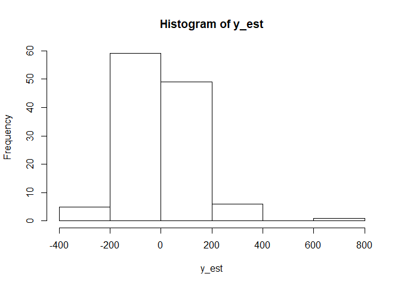

```r
iter <- 2
pi_k <- pi_est_list[[iter-1]]
q_c_matrix <- matrix(0, nrow = n, ncol = K_up)
for(k in 1:K_up){
  q_c_matrix[,k] <- dnorm(y_est_list[[iter-1]],
                          mean = mu_est_list[[iter-1]][k],
                          sd = 1/rho_est_list[[iter-1]][k])
}
q_c_matrix <- q_c_matrix * kronecker(matrix(1, nrow = n, ncol = 1), matrix(pi_k, nrow = 1))
q_c_matrix <- q_c_matrix/apply(q_c_matrix, 1, sum)
y_est <- apply((whole.data$X %*% matrix(coef_beta_est_list[[iter-1]], ncol=K_up) +
    whole.data$Z %*% matrix(coef_alpha_est_list[[iter-1]], ncol=K_up) +
    whole.data$W %*% matrix(coef_eta_est_list[[iter-1]], ncol=K_up)) * q_c_matrix, 1, sum)
hist(y_est)
```

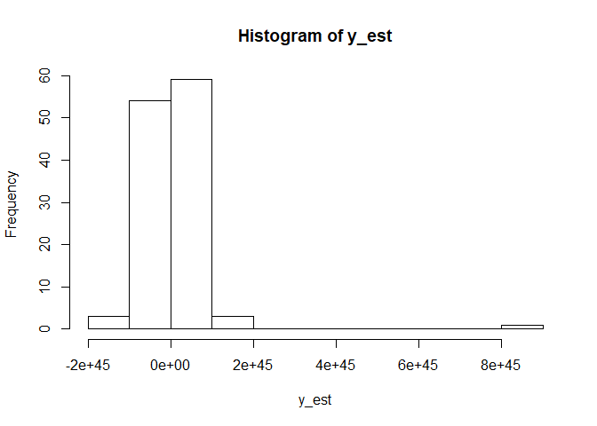

```r
iter <- 3
pi_k <- pi_est_list[[iter-1]]
q_c_matrix <- matrix(0, nrow = n, ncol = K_up)
for(k in 1:K_up){
  q_c_matrix[,k] <- dnorm(y_est_list[[iter-1]],
                          mean = mu_est_list[[iter-1]][k],
                          sd = 1/rho_est_list[[iter-1]][k])
}
q_c_matrix <- q_c_matrix * kronecker(matrix(1, nrow = n, ncol = 1), matrix(pi_k, nrow = 1))
q_c_matrix <- q_c_matrix/apply(q_c_matrix, 1, sum)
y_est <- apply((whole.data$X %*% matrix(coef_beta_est_list[[iter-1]], ncol=K_up) +
    whole.data$Z %*% matrix(coef_alpha_est_list[[iter-1]], ncol=K_up) +
    whole.data$W %*% matrix(coef_eta_est_list[[iter-1]], ncol=K_up)) * q_c_matrix, 1, sum)
hist(y_est)
```